# R Notebook

##### Loading the Libraries required for the analysis

```r
library(FSelector)  # Feature Selection
library(tidyverse)
library(tree) # Decision Tree
library(gbm)  # Boosting
library(rpart)
library(rpart.plot)
library(randomForest) # Bagging and Random Forest
```

##### Loading the Dataset NSDUH_2020.Rdata

```r
load("/Users/kat/Documents/SeattleU/Spring 23/Written Homework-1/NSDUH_2020.Rdata")
```

##### Data Pre-Processing

Followed the steps from the Youth.R

```r
# select those that answered the youth experiences questions
youth <- NSDUH_2020[!is.na(NSDUH_2020$schfelt),]  #  There are 5500 observations

# make a vector of substance use column names
substance_cols <- c(   'iralcfy',# quantitative values for frequency of use
                       'irmjfy', # marijuana frequency past year (1-365)
                       'irmjfm', # marijuana frequency past month (1-30)

                       # quantitative values for age of first use
                       'irmjage', # marijuana age of first use (1-83), 991=never used

                       # binary categories for use at all
                       'mrjflag', # marijuana ever used (0=never, 1=ever)
                       'alcflag', # alcohol ever used (0=never, 1=ever)
                       'tobflag', # tobacco ever used (0=never, 1=ever)

                       # multiclass categories for frequency of use
                       'alcmdays',# number of days of alcohol in past month (1-4 categories, 5=none)
                       'cigmdays',# number of days of cigarette in past month (1-4 categories, 5=none)
                       'iralcrc', # how recently alcohol was used (1-3 categories,9 = never)
                       'mrjydays','alcydays', # number of days of marijuana and alcohol in past year (1-5 categories, 6=none)
                       'mrjmdays', # number of days of marijuana in past month (1-4 categories, 5=none)
                       'ysdssoc' # Youth major depression episode (1-5 categories)
    )

# make a vector of demographic column names
demographic_cols <- c(
                  'irsex', # binary sex (1=male, 2=female)
                  'NEWRACE2', # race (7 categories)
                  'HEALTH2', # overall health (4 categories)
                  'eduschlgo', # now going to school (1=yes, 2=no)
                  'EDUSCHGRD2', # what grade in now/will be in (11 categories, 98,99= blank/skip)
                  'eduskpcom', #how many days skipped school in past month (1-30, 94/97/98/99=blank/skip)
                  'imother', # for youth, mother in household (1=yes, 2=no, 3=don't know, 4=over 18)
                  'ifather', # for youth, father in household (1=yes, 2=no, 3=don't know, 4=over 18)
                  'income', # total family income (4 categories)
                  'govtprog', # got gov assistance (1=yes, 2=no)
                  'POVERTY3', # poverty level (4 categories)
                  'PDEN10', # population density (1= >1M people, 2=<1M people, 3=can't be determined)
                  'COUTYP4' # metro size status (1=large metro, 2=small metro, 3=nonmetro)
                  )

# Other variables which could possibly have influence:
col_1 <- c('ymdelt','CATAG7','drvindrg','uadfwho','irwrkstat','rskmrjwk') #,'stndsmj'
# select columns of interest
df_dep <- youth %>% select(col_1)
df_youth <- youth %>% select(schfelt:rlgfrnd) # use all youth questions, start with schfelt and go through rlgfrnd
df_substance <- youth %>% select(substance_cols) # select specific substance columns of interest
df_demog <- youth %>% select(demographic_cols)  # select specific demographic columns of interest

# combine into one data frame
df = cbind(df_dep,df_substance, df_youth, df_demog) #combine into one data frame

# Replacing a meaningful value

df["irmjfy"][df["irmjfy"] == 991 | df["irmjfy"] == 993] <- 0
df["iralcfy"][df["iralcfy"] == 991 | df["iralcfy"] == 993] <- 0
df["irmjfm"][df["irmjfm"] == 91 | df["irmjfm"] == 93] <- 0
df["irmjage"][df["irmjage"] == 991 ] <- 0
df["rskmrjwk"][df["rskmrjwk"] == 85 | df["rskmrjwk"] == 94 | df["rskmrjwk"] == 98 | df["rskmrjwk"] == 97] <- 0


# make vector of columns from the data that should be converted to factors, unordered and ordered
unordered_factor_cols <- c(names(df_youth),"ymdelt","rskmrjwk",# all columns from youth
                           'CATAG7','uadfwho','irwrkstat','ysdssoc','alcmdays','iralcrc','mrjydays',
                           'mrjflag','alcflag','tobflag','drvindrg', # binary flag columns from substance
                           'irsex','NEWRACE2','eduschlgo','imother','ifather','govtprog','PDEN10','COUTYP4' # unordered categories for demographics
                           )
ordered_factor_cols <- c('EDUSCHGRD2','HEALTH2','POVERTY3','income','mrjmdays',"alcydays")

# convert to factors
df[unordered_factor_cols] <- lapply(df[unordered_factor_cols], factor) # correct columns to unordered factors (e.g. yes, no)
df[ordered_factor_cols] <- lapply(df[ordered_factor_cols], factor, ordered=TRUE) # correct columns to ordered factors (e.g. small, medium, large)
```

Imputing the missing values values with mode if it is a factor or with mean if it is a numeric

```r
# loop through all columns
for (col in names(df)) {
  # check if column is a factor
  if (is.factor(df[[col]])) {
    # replace missing values with the mode
    df[[col]][is.na(df[[col]])] <- names(sort(table(df[[col]]), decreasing = TRUE))[1]
  }
  # check if column is numeric
  else if (is.numeric(df[[col]])) {
    # replace missing values with the mean
    df[[col]][is.na(df[[col]])] <- mean(df[[col]], na.rm = TRUE)
  }
}
```

##### Feature Selection using Information gain for the consumption of Marijuana

```r
info_gain_1 <- information.gain(mrjflag ~ ., data=df)
info_gain_1
```

|  | attr_importance |
| --- | --- |
| ymdelt | 1.919931e-02 |
| CATAG7 | 5.021008e-02 |
| drvindrg | 4.014307e-02 |
| uadfwho | 4.504849e-02 |
| irwrkstat | 4.658882e-02 |
| rskmrjwk | 8.941555e-02 |
| iralcfy | 1.207087e-01 |
| irmjfy | 3.013673e-01 |
| irmjfm | 1.445204e-01 |
| irmjage | 4.075951e-01 |

[output cut: 69 more lines]

Subsetting the significant variables related to the marijuana for the analysis

Note : Ignoring other marijuna related variables as they are highly correlated, we need to identify the other factors that potentially affect.

```r
df1 <- df%>% select(c('mrjflag','FRDMEVR2','stndalc','prmjmo','irwrkstat','eduskpcom','HEALTH2','tobflag','EDUSCHGRD2','uadfwho','stndsmj','FRDPCIG2','ysdssoc'))
```

##### Splitting of Training and Test datasets

```r
set.seed(5)
train <- sample(1:nrow(df1), nrow(df1)*0.7)
NSDUH_train_set <- df1[train,]
NSDUH_test_set <- df1[-train,]
```

##### Model 1 - Consumption of Marijuana in Teens

Decision Tree

Ignoring the Other drug related parameters

```r
model_1 <-tree(mrjflag ~ FRDMEVR2+stndalc+prmjmo+irwrkstat+eduskpcom+HEALTH2+tobflag+EDUSCHGRD2+uadfwho+stndsmj+FRDPCIG2+ysdssoc,
               NSDUH_train_set)
summary(model_1)
```

```
Classification tree:
tree(formula = mrjflag ~ FRDMEVR2 + stndalc + prmjmo + irwrkstat +
    eduskpcom + HEALTH2 + tobflag + EDUSCHGRD2 + uadfwho + stndsmj +
    FRDPCIG2 + ysdssoc, data = NSDUH_train_set)
Variables actually used in tree construction:
[1] "FRDMEVR2"  "tobflag"   "stndsmj"   "irwrkstat" "uadfwho"
Number of terminal nodes:  8
Residual mean deviance:  0.453 = 1740 / 3841
Misclassification error rate: 0.09275 = 357 / 3849
```

Performance of the model on test dataset

```r
m1test_pred <- predict(model_1,NSDUH_test_set,type="class")
table(m1test_pred,NSDUH_test_set$mrjflag)
```

```
m1test_pred    0    1
          0 1394  138
          1   24   95
```

```r
print(paste(" Accuracy of test set :",round(mean((m1test_pred == NSDUH_test_set$mrjflag)) *100)," %"))
```

```
[1] " Accuracy of test set : 90  %"
```

Pruning the tree to reduce the complexity of the model and to check if the accuracy of the model can be improved

###### Cross-Validation to select the optimum tree size

```r
# Using cross validation
set.seed(0)
cv.model1 <- cv.tree(model_1)
cv.model1
```

```
$size
[1] 8 7 6 5 4 3 2 1

$dev
[1] 1768.729 1835.192 1835.192 1987.761 1990.208 2157.057 2436.159 3142.099

$k
[1]      -Inf  38.40967  38.79493  76.11802  84.35091 176.23833 279.30715 706.55648

$method
[1] "deviance"

attr(,"class")
[1] "prune"         "tree.sequence"
```

```
integer(0)
```

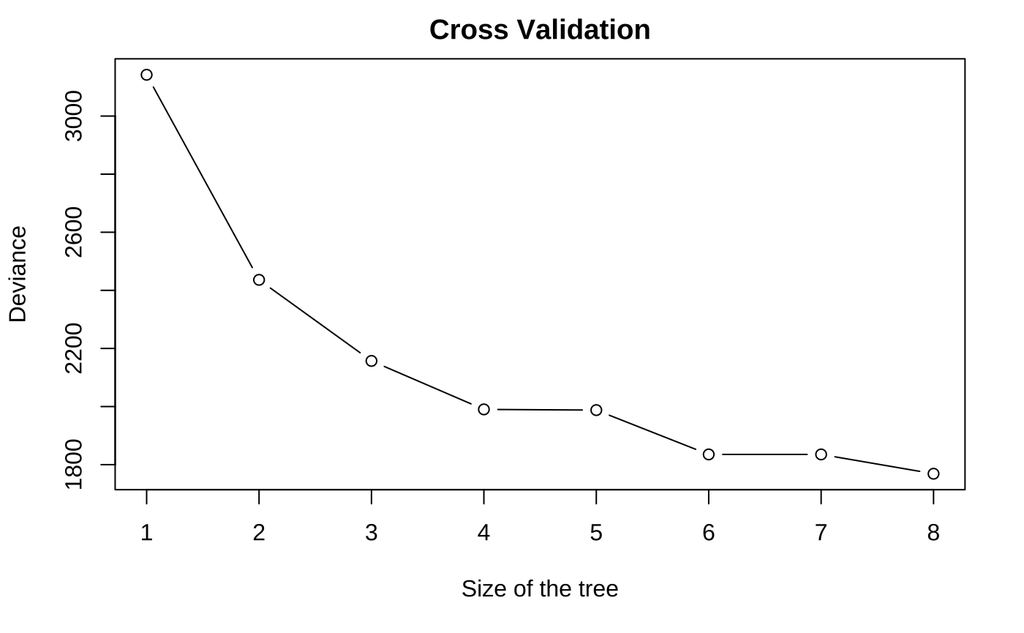

```r
plot(cv.model1$size,cv.model1$dev,type="b",xlab = "Size of the tree",ylab = "Deviance")+title("Cross Validation")
```

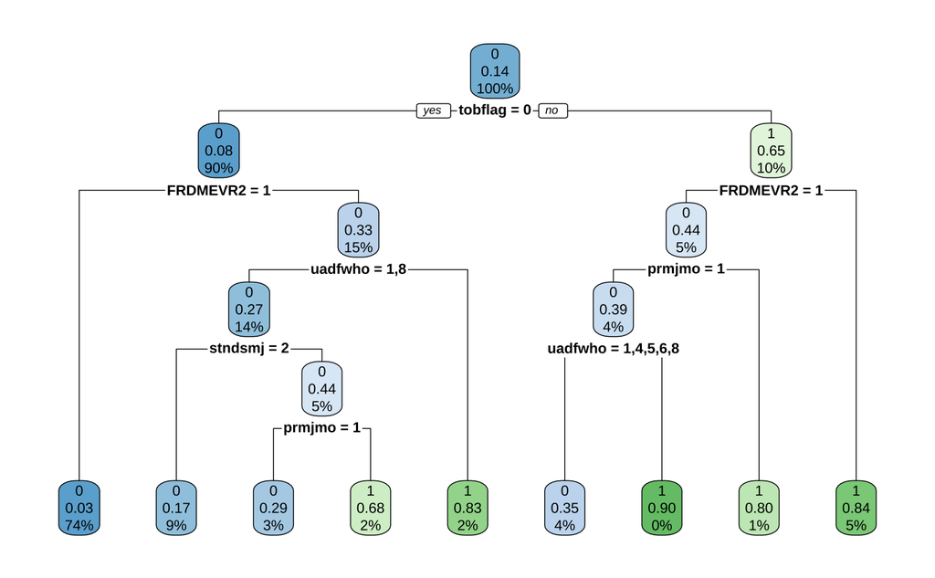

```r
# Pruning the tree

prune.model1 <- prune.misclass(model_1,best=6)
df_rpart_1_pruned <- rpart(model_1, data = NSDUH_train_set)
rpart.plot(df_rpart_1_pruned )
```

```r
# Predicting the  training and test set with the pruned tree model
prune.pred <- predict(prune.model1,NSDUH_train_set,type="class")
table(prune.pred,NSDUH_train_set$mrjflag)
```

```
prune.pred    0    1
         0 3249  302
         1   55  243
```

```r
print(paste(" Accuracy for the Training set of the pruned tree model",round(mean(prune.pred == NSDUH_train_set$mrjflag)*100),"%"))
```

```
[1] " Accuracy for the Training set of the pruned tree model 91 %"
```

```r
prune.pred <- predict(prune.model1,NSDUH_test_set,type="class")
table(prune.pred,NSDUH_test_set$mrjflag)
```

```
prune.pred    0    1
         0 1394  138
         1   24   95
```

```r
print(paste(" Accuracy for the Test set of the pruned tree model",round(mean(prune.pred == NSDUH_test_set$mrjflag)*100),"%"))
```

```
[1] " Accuracy for the Test set of the pruned tree model 90 %"
```

Pruning the tree have’nt improved the performance of the tree model.

###### The Ensembel Methods:

Bagging:

```r
bag.model1 <- randomForest(mrjflag ~ ., data = NSDUH_train_set, mtry =length(NSDUH_train_set) , importance = TRUE)
bag.model1
```

```
Call:
 randomForest(formula = mrjflag ~ ., data = NSDUH_train_set, mtry = length(NSDUH_train_set),      importance = TRUE)
               Type of random forest: classification
                     Number of trees: 500
No. of variables tried at each split: 12

        OOB estimate of  error rate: 10.47%
Confusion matrix:
     0   1 class.error
0 3137 167  0.05054479
1  236 309  0.43302752
```

Performance of bagging on Training and Test dataset:

```r
yhat.train.bag <- predict(bag.model1, newdata = NSDUH_train_set,type="class")
print(paste("TPerformance of bagging on Training data:",round(mean(yhat.train.bag ==NSDUH_train_set$mrjflag)*100),"%"))
```

```
[1] "TPerformance of bagging on Training data: 98 %"
```

```r
table(yhat.train.bag,NSDUH_train_set$mrjflag)
```

```
yhat.train.bag    0    1
             0 3297   65
             1    7  480
```

```r
yhat.test.bag <- predict(bag.model1, newdata = NSDUH_test_set,type="class")
print(paste("Performance of bagging on Test data:",round(mean(yhat.test.bag ==NSDUH_test_set$mrjflag)*100),"%"))
```

```
[1] "Performance of bagging on Test data: 89 %"
```

```r
table(yhat.test.bag,NSDUH_test_set$mrjflag)
```

```
yhat.test.bag    0    1
            0 1340  105
            1   78  128
```

The model is overfitting the training data and reduced performance in the test data.

To check the nodal purity using Ginni index

```r
importance(bag.model1)
```

```
                   0          1 MeanDecreaseAccuracy MeanDecreaseGini
FRDMEVR2   -1.008269  58.577620            41.174768        133.78910
stndalc    11.231091  -3.894171             7.743830         30.43857
prmjmo     21.740973  35.387820            39.073941         37.33239
irwrkstat  -7.936425   8.114678            -1.960898         59.09321
eduskpcom   8.827129  -9.567996             3.753391         63.23305
HEALTH2    -3.304482 -14.601570           -11.485094         62.31759
tobflag    57.028090  84.518733            88.816044        217.10420
EDUSCHGRD2  5.951392   9.406214            11.362934         85.33120
uadfwho    32.439117  51.562815            51.801306         74.13098
stndsmj     7.936618  43.619258            34.897579         44.98101
FRDPCIG2   24.175877  -8.499493            16.850213         17.57459
ysdssoc     1.187423   4.344600             3.784638         37.64326
```

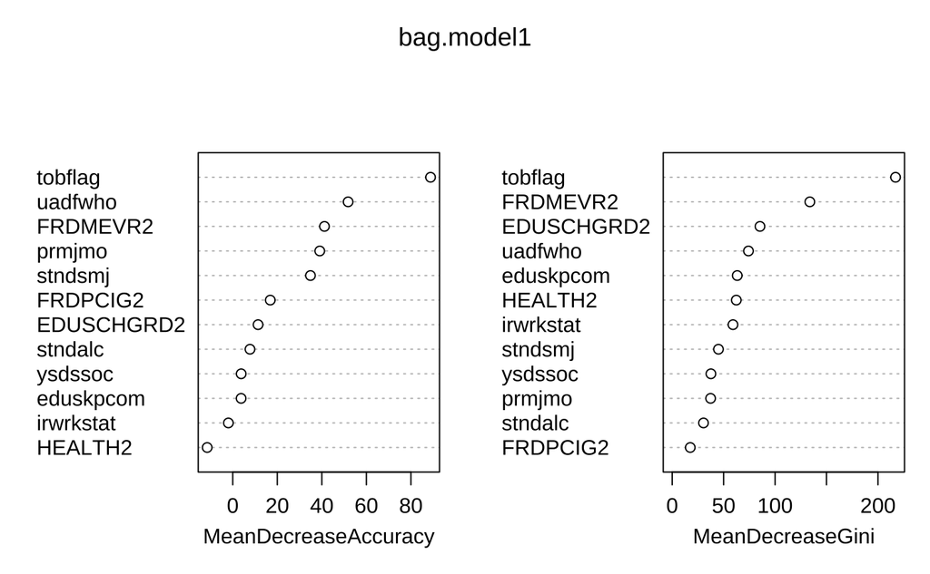

```r
varImpPlot(bag.model1)
```

Consumption of tobacco and peer’s opinion on the drug consumption are vital factors in determining the response variable (usage of marijuana)

Random Forest method :

```r
set.seed(5)

p <- seq(1,length(NSDUH_train_set),by=1)
error<-c( )

for(i in 1:length(p))
{
  rf.model1 <- randomForest(mrjflag ~ ., data = NSDUH_train_set, mtry = i, importance = TRUE)
yhat.rf <- predict(rf.model1, newdata = NSDUH_test_set)
error[i] = mean(yhat.rf!= NSDUH_test_set$mrjflag)

}
```

Plotting the error rate for different subset of parameters:

```r
plot(p,error,type="b",xlab ="Subset of paramter",ylab=" Test MSE")+ title(" Cross- validation for the optimal subset of parameters")
```

```
integer(0)
```

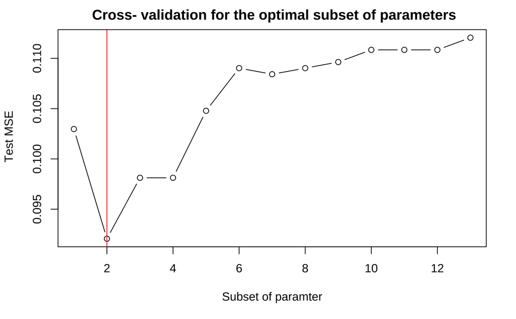

```r
index<- which.min(round(error,3)) # Index of the minimum MSE
Min_error <- error[index]
min_p <- p[index]
abline(v=min_p,col="red")
```

```r
#text(min_p,Min_error,"Least Mse")
best_subset = min_p

print(paste("Best number of subset of variable selection is : ",best_subset," has the test error rate of :",round(Min_error,2)))
```

```
[1] "Best number of subset of variable selection is :  2  has the test error rate of : 0.09"
```

```r
bag.model1e <- randomForest(mrjflag ~ ., data = NSDUH_train_set, mtry = 2,ntree=1000,importance = TRUE)
bag.model1a <- randomForest(mrjflag ~ ., data = NSDUH_train_set, mtry = 5,ntree=1000,importance = TRUE)
bag.model1b <- randomForest(mrjflag ~ ., data = NSDUH_train_set, mtry = 7,ntree=1000, importance = TRUE)
bag.model1c <- randomForest(mrjflag ~ ., data = NSDUH_train_set, mtry = 9,ntree=1000,importance = TRUE)
bag.model1d <- randomForest(mrjflag ~ ., data = NSDUH_train_set, mtry = 13,ntree=1000,importance = TRUE)
```